# Restaurant Dataset

# We Will Plot Top-3 City from Each Country which having the Maximum Branches of Restaurants

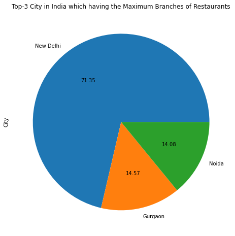

```python
plt.figure(figsize=(10,8))
India_city_rest['City'].value_counts()[:3].plot(kind='pie',autopct='%.2f')
plt.title('Top-3 City in India which having the Maximum Branches of Restaurants')
plt.show()
```

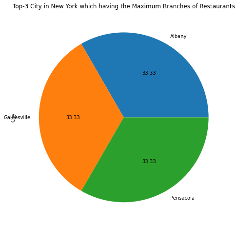

```python
plt.figure(figsize=(10,8))
New_York_city_rest['City'].value_counts()[:3].plot(kind='pie',autopct='%.2f')
plt.title('Top-3 City in New York which having the Maximum Branches of Restaurants')
plt.show()
```

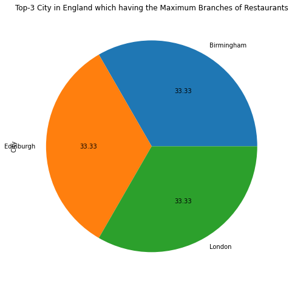

```python
plt.figure(figsize=(10,8))
England_city_rest['City'].value_counts()[:3].plot(kind='pie',autopct='%.2f')
plt.title('Top-3 City in England which having the Maximum Branches of Restaurants')
plt.ylabel('City')
plt.show()
```

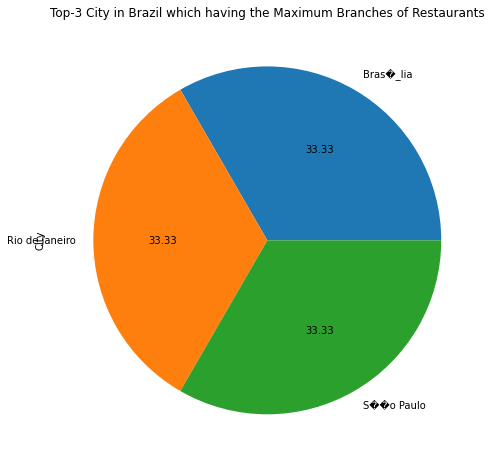

```python
plt.figure(figsize=(10,8))
Brazil_city_rest['City'].value_counts()[:3].plot(kind='pie',autopct='%.2f')
plt.title('Top-3 City in Brazil which having the Maximum Branches of Restaurants')
plt.show()
```

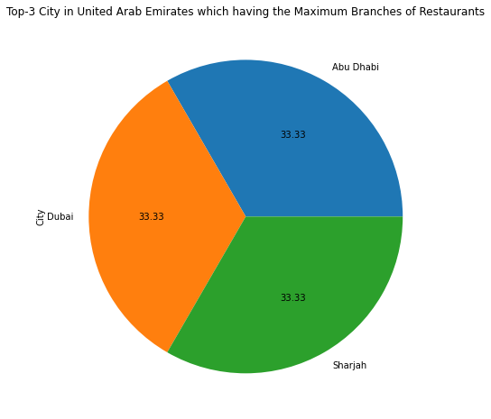

```python
plt.figure(figsize=(10,8))
United_Arab_Emirates_city_rest['City'].value_counts()[:3].plot(kind='pie',autopct='%.2f')
plt.title('Top-3 City in United Arab Emirates which having the Maximum Branches of Restaurants')
plt.show()
```

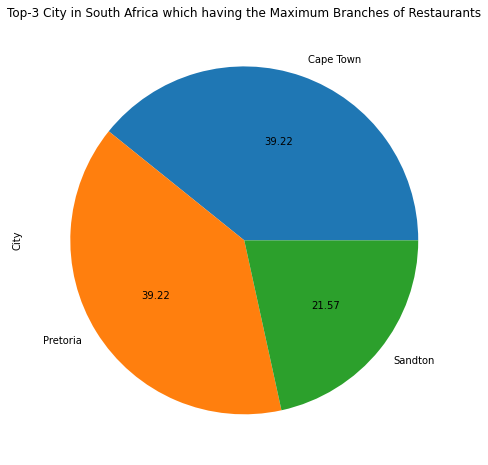

```python
plt.figure(figsize=(10,8))
South_Africa_city_rest['City'].value_counts()[:3].plot(kind='pie',autopct='%.2f')
plt.title('Top-3 City in South Africa which having the Maximum Branches of Restaurants')
plt.show()
```

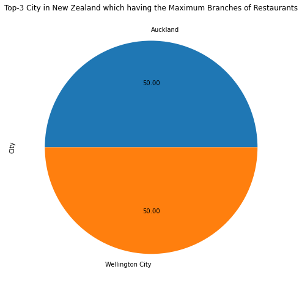

```python
plt.figure(figsize=(10,8))
New_Zealand_city_rest['City'].value_counts()[:3].plot(kind='pie',autopct='%.2f')
plt.title('Top-3 City in New Zealand which having the Maximum Branches of Restaurants')
plt.show()
```

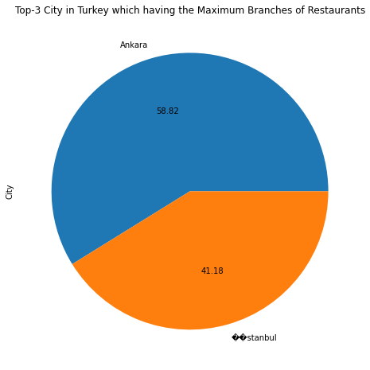

```python
plt.figure(figsize=(10,8))
Turkey_city_rest['City'].value_counts()[:3].plot(kind='pie',autopct='%.2f')
plt.title('Top-3 City in Turkey which having the Maximum Branches of Restaurants')
plt.show()
```

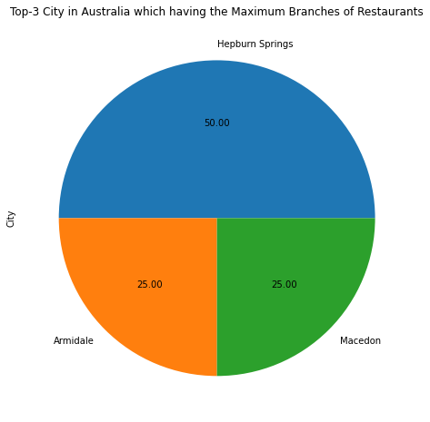

```python
plt.figure(figsize=(10,8))
Australia_city_rest['City'].value_counts()[:3].plot(kind='pie',autopct='%.2f')
plt.title('Top-3 City in Australia which having the Maximum Branches of Restaurants')
plt.show()
```

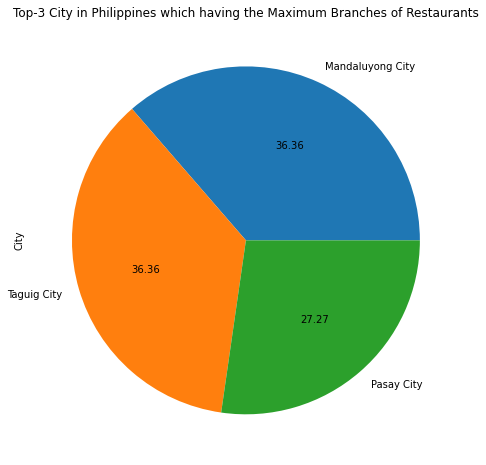

```python
plt.figure(figsize=(10,8))
Philippines_city_rest['City'].value_counts()[:3].plot(kind='pie',autopct='%.2f')
plt.title('Top-3 City in Philippines which having the Maximum Branches of Restaurants')
plt.show()
```

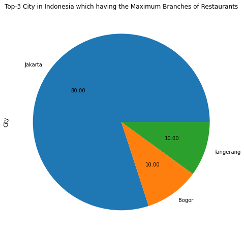

```python
plt.figure(figsize=(10,8))
Indonesia_city_rest['City'].value_counts()[:3].plot(kind='pie',autopct='%.2f')
plt.title('Top-3 City in Indonesia which having the Maximum Branches of Restaurants')
plt.show()
```

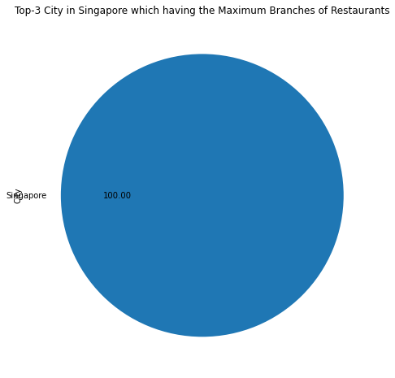

```python
plt.figure(figsize=(10,8))
Singapore_city_rest['City'].value_counts()[:3].plot(kind='pie',autopct='%.2f')
plt.title('Top-3 City in Singapore which having the Maximum Branches of Restaurants')
plt.show()
```

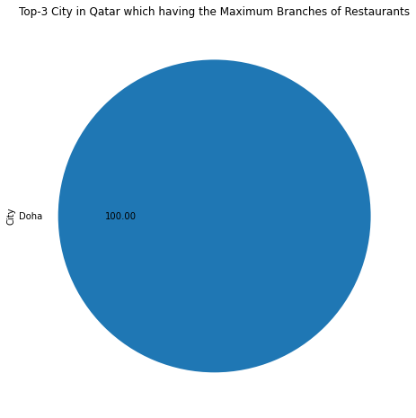

```python
plt.figure(figsize=(10,8))
Qatar_city_rest['City'].value_counts()[:3].plot(kind='pie',autopct='%.2f')
plt.title('Top-3 City in Qatar which having the Maximum Branches of Restaurants')
plt.show()
```

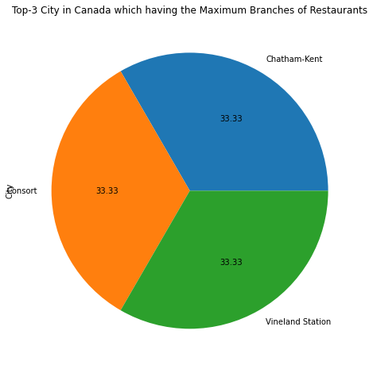

```python
plt.figure(figsize=(10,8))
Canada_city_rest['City'].value_counts()[:3].plot(kind='pie',autopct='%.2f')
plt.title('Top-3 City in Canada which having the Maximum Branches of Restaurants')
plt.show()
```

```python
cat_cols['Cuisines'].value_counts()[:1]
```

```
North Indian    936
Name: Cuisines, dtype: int64
```

```python
print('Observation: The maximun Cuisines the restaurant has served if North Indian')
```

```
Observation: The maximun Cuisines the restaurant has served if North Indian
```

# Things to Perform:

#### Geospatial Analysis Visualize the locations of restaurants on a map using latitude and longitude information.

#### Analyze the distribution of restaurants across different cities or countries.

#### Determine if there is any correlation between the restaurant's location and its rating.

```python
pip install folium pandas
```

```python
data.head(2)
```

|  | Restaurant ID | Restaurant Name | Country Code | City | Address | Locality | Locality Verbose | Longitude | Latitude | Cuisines | ... | Price range | Aggregate rating | Rating color | Rating text | Votes | Has_Table_booking_Encoded | Has_Online_delivery_Encoded | Is_delivering_now_Encoded | Switch_to_order_menu_Encoded | Country_Code_Encoded |
| --- | --- | --- | --- | --- | --- | --- | --- | --- | --- | --- | --- | --- | --- | --- | --- | --- | --- | --- | --- | --- | --- |
| 0 | 6317637 | Le Petit Souffle | 162 | Makati City | Third Floor, Century City Mall, Kalayaan Avenu... | Century City Mall, Poblacion, Makati City | Century City Mall, Poblacion, Makati City, Mak... | 121.027535 | 14.565443 | French, Japanese, Desserts | ... | 3 | 4.8 | Dark Green | Excellent | 314 | 1 | 0 | 0 | 0 | Philippines |
| 1 | 6304287 | Izakaya Kikufuji | 162 | Makati City | Little Tokyo, 2277 Chino Roces Avenue, Legaspi... | Little Tokyo, Legaspi Village, Makati City | Little Tokyo, Legaspi Village, Makati City, Ma... | 121.014101 | 14.553708 | Japanese | ... | 3 | 4.5 | Dark Green | Excellent | 591 | 1 | 0 | 0 | 0 | Philippines |

2 rows × 26 columns

```python
lat_long_India=data[data['Country_Code_Encoded']=='India']
```

```python
lat_long_India=data[data['Country_Code_Encoded']=='India']
lat_long_New_York=data[data['Country_Code_Encoded']=='New York']
lat_long_England=data[data['Country_Code_Encoded']=='England']
lat_long_Brazil=data[data['Country_Code_Encoded']=='Brazil']
lat_long_United_Arab_Emirates=data[data['Country_Code_Encoded']=='United Arab Emirates']
lat_long_South_Africa=data[data['Country_Code_Encoded']=='South Africa']
lat_long_New_Zealand=data[data['Country_Code_Encoded']=='New Zealand']
lat_long_Turkey=data[data['Country_Code_Encoded']=='Turkey']
lat_long_Australia=data[data['Country_Code_Encoded']=='Australia']
lat_long_Philippines=data[data['Country_Code_Encoded']=='Philippines']
lat_long_Indonesia=data[data['Country_Code_Encoded']=='Indonesia']
lat_long_Singapore=data[data['Country_Code_Encoded']=='Singapore']
lat_long_Qatar=data[data['Country_Code_Encoded']=='Qatar']
lat_long_Sri_lanka=data[data['Country_Code_Encoded']=='Sri Lanka']
lat_long_Canada=data[data['Country_Code_Encoded']=='Canada']
```

```python
import pandas as pd
import folium
from IPython.display import IFrame

data=pd.DataFrame(data)

# Create a map centered around an average location
map_center = [lat_long_India['Latitude'].mean(), lat_long_India['Longitude'].mean()]
restaurant_map = folium.Map(location=map_center, zoom_start=5)

# Add markers to the map
for _, row in lat_long_India.iterrows():
    folium.Marker(
        location=[row['Latitude'], row['Longitude']],
        popup=f"Restaurant: {row['Restaurant Name']}"
    ).add_to(restaurant_map)

# Save the map to an HTML file
restaurant_map.save('restaurant_map.html')

# Display the map in a Jupyter notebook
IFrame('restaurant_map.html', width=700, height=500)
```

[interactive chart not shown]

```python
import pandas as pd
import folium
from IPython.display import IFrame

data=pd.DataFrame(data)

# Create a map centered around an average location
map_center = [lat_long_England['Latitude'].mean(), lat_long_England['Longitude'].mean()]
restaurant_map = folium.Map(location=map_center, zoom_start=5)

# Add markers to the map
for _, row in lat_long_England.iterrows():
    folium.Marker(
        location=[row['Latitude'], row['Longitude']],
        popup=f"Restaurant: {row['Restaurant Name']}"
    ).add_to(restaurant_map)

# Save the map to an HTML file
restaurant_map.save('restaurant_map.html')

# Display the map in a Jupyter notebook
IFrame('restaurant_map.html', width=700, height=500)
```

[interactive chart not shown]

```python
Determine if there is any correlation between the restaurant's location and its rating
```

```python
cov=data[['Locality Verbose','Aggregate rating']]
```

```python
cov.corr()
```

|  | Aggregate rating |
| --- | --- |
| Aggregate rating | 1.0 |

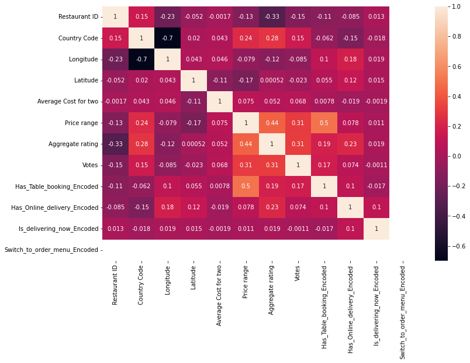

```python
plt.figure(figsize=(12,8))
sns.heatmap(data.corr(), annot=True)
plt.show()
```

# Things to Perform:

### Table Booking and Online Delivery

### Determine the percentage of restaurants that offer table booking and online delivery.

### Compare the average ratings of restaurants with table booking and those without.

### Analyze the availability of online delivery among restaurants with different price ranges.

```python
data.head(2)
```

|  | Restaurant ID | Restaurant Name | Country Code | City | Address | Locality | Locality Verbose | Longitude | Latitude | Cuisines | ... | Price range | Aggregate rating | Rating color | Rating text | Votes | Has_Table_booking_Encoded | Has_Online_delivery_Encoded | Is_delivering_now_Encoded | Switch_to_order_menu_Encoded | Country_Code_Encoded |
| --- | --- | --- | --- | --- | --- | --- | --- | --- | --- | --- | --- | --- | --- | --- | --- | --- | --- | --- | --- | --- | --- |
| 0 | 6317637 | Le Petit Souffle | 162 | Makati City | Third Floor, Century City Mall, Kalayaan Avenu... | Century City Mall, Poblacion, Makati City | Century City Mall, Poblacion, Makati City, Mak... | 121.027535 | 14.565443 | French, Japanese, Desserts | ... | 3 | 4.8 | Dark Green | Excellent | 314 | 1 | 0 | 0 | 0 | Philippines |
| 1 | 6304287 | Izakaya Kikufuji | 162 | Makati City | Little Tokyo, 2277 Chino Roces Avenue, Legaspi... | Little Tokyo, Legaspi Village, Makati City | Little Tokyo, Legaspi Village, Makati City, Ma... | 121.014101 | 14.553708 | Japanese | ... | 3 | 4.5 | Dark Green | Excellent | 591 | 1 | 0 | 0 | 0 | Philippines |

2 rows × 26 columns

```python
data['Has Table booking'].value_counts()
```

```
No     8393
Yes    1158
Name: Has Table booking, dtype: int64
```

```python
(data['Has Table booking'].value_counts()[1]/len(data))*100
```

```
12.124384881164275
```

```python
print('Observation: Out of 100%, only 12% of restaurants book the table for the customers')
```

```
Observation: Out of 100%, only 12% of restaurants book the table for the customers
```

```python
(data['Has Table booking'].value_counts()[0]/len(data))*100
```

```
87.87561511883573
```

```python
print('Observation: Out of 100%, a majority of 87% of restaurants do not take the booking of restaurants for the customers')
```

```
Observation: Out of 100%, a majority of 87% of restaurants do not take the booking of restaurants for the customers
```

```python
data['Has Online delivery'].value_counts()
```

```
No     7100
Yes    2451
Name: Has Online delivery, dtype: int64
```

```python
(data['Has Online delivery'].value_counts()[0]/len(data))*100
```

```
74.33776567898649
```

```python
print('74% of restaurants do not take the Online Delivery')
```

[output not shown]

```python
(data['Has Online delivery'].value_counts()[1]/len(data))*100
```

```
25.662234321013504
```

```python
print('25% of restaurants tend to have the Online Delivery')
```

```
25% of restaurants tend to have the Online Delivery
```

# Determine the percentage of restaurants that offer table booking and online delivery.

```python
both_table_online=data[(data['Has_Table_booking_Encoded']==1) & (data['Has_Online_delivery_Encoded']==1)]
```

```python
both_table_online['Country_Code_Encoded'].value_counts()
```

```
India                   427
United Arab Emirates      8
Name: Country_Code_Encoded, dtype: int64
```

```python
print('Observation: We can clealy observe there are only 2 countries that have the option of Online Delivery and Table Booking')
```

```
Observation: We can clealy observe there are only 2 countries that have the option of Online Delivery and Table Booking
```

```python
print('Observation: In India 427 restaurants and In UAE 8 restaurants having the facility of Table booking and Online Delivery')
```

```
Observation: In India 427 restaurants and In UAE 8 restaurants having the facility of Table booking and Online Delivery
```

```python
rest_table_online=(both_table_online.value_counts().sum()/len(data))*100
rounded_percentage = round(rest_table_online, 0)

print(f"Rounded Percentage: {rounded_percentage}")
```

```
Rounded Percentage: 5.0
```

```python
print('Only, 5% of Overall restaurants take both the Online Order and Table Booking')
```

```
Only, 5% of Overall restaurants take both the Online Order and Table Booking
```

```python
#Compare the average ratings of restaurants with table booking and those without.
```

```python
table_booked=data[data['Has_Table_booking_Encoded']==1]
```